# Northwest Syria Cash Working Group Proposed Revision to Targets

24 March 2023

# Overall cash working group targets

This document proposes new targets for 2023 for the Cash Working Group; targets have not been updated since the flash appeal on 12 February 2023. New assessment data has been made available since then, necessitating the change.

The proposed new targets Cash Working Group should take into account the sum of **persons completely unable to meet their basic needs** (identified as 8% of the population in the HNO; this was the basis for the original target) and the number of **persons in immediate needs of shelter and NFI support** (which the Shelter Cluster has [estimated](https://sheltercluster.s3.eu-central-1.amazonaws.com/public/docs/EQ-SitRep-14Mar-vEN.pdf?VersionId=q2PaLZGoorIMaaLJVPtd7ca6HDmp0lpO) at 265,000 persons whose houses have been completely damaged and 224,231 persons whose houses have received major damage.

Based on these figures, two options for new targets are being proposed:

Options for CWG revised target

| group | persons |
| --- | --- |
| unable_to_meet_basic_needs | 397,924 |
| complete_damage | 265,000 |
| major_damage | 224,231 |
| target_option1a | 887,155 |
| target_option2b | 662,924 |

aunable to meet needs + complete damage + major damage  
bunable to meet needs + complete damage

*Update*: **Target option 2, or 662,924 persons, has been selected**, based on partners’ current capacity to meet needs. Additionally, the population whose houses have been completely or severely damaged should be prioritised above the populations whose houses have received major damage.

Partner capacities and community-level needs will be reassessed regularly. Should the situation change or new data be made available, the targets will also be correspondingly be updated.

# Preliminary sub-district-level allocation

Furthermore, the Cash Working Group has also conducted a preliminary allocation of these new proposed targets at the sub-district (admin3) level.

This preliminary allocation has been based on the combination of four variables, taking into account both the magnitude and severity of the earthquake’s impact:

- The number of persons wounded and dead
- The number of persons wounded and dead per 100,000 persons
- The number of completely and partially-damaged houses
- The number of completely and partially-damaged houses per 100,000 persons

When explaining to partners and communities how sub-district level targets have been set, it can be easily explained that a score was developed based on the above four variables.

For a more detailed explanation, please see this document on the [Betti-Verma formula](http://medim.ceps.lu/stata/mdepriv_v3.pdf) to understand the math behind how these variables were weighted. Though, in brief, the Betti-Vermi formula is a method for selecting a subset of predictor variables in a multiple regression model, while accounting for the presence of multicollinearity among the predictors. The criterion is based on the concept of “contribution”, which is defined as the degree to which a predictor variable contributes to the prediction of the outcome variable, over and above the contributions of the other predictor variables in the model.

The Betti-Verma method aims to select a subset of independent variables that have a low variance inflation factor (VIF), which indicates a low degree of multicollinearity. By selecting a subset of independent variables with a low VIF, the method can improve the accuracy and interpretability of the regression model, resulting in a model which penalises redundancy and rewards variation.

A **sub-district-level breakdown** of these new proposed targets may be downloaded **[here](https://github.com/northwest-syria-cash-working-group/new_cash_targets/raw/main/data/proposed_targets_preliminary_allocation.xlsx)**. Bear in mind that we have selected **Option 2**.

### Plots and visual proof

This is a slightly technical section with more detail on the validity of the calculated earthquake scores.

The plots below show the magnitude and severity of the wounded and dead and damaged houses, respectively. Magnitude is shown on the x-axis and severity on the y-axis.

The calculated earthquake score, which roughly translates to each sub-district’s share of the overall earthquake impact is marked by the size of each point.

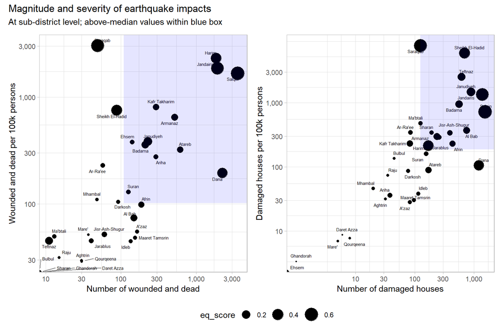

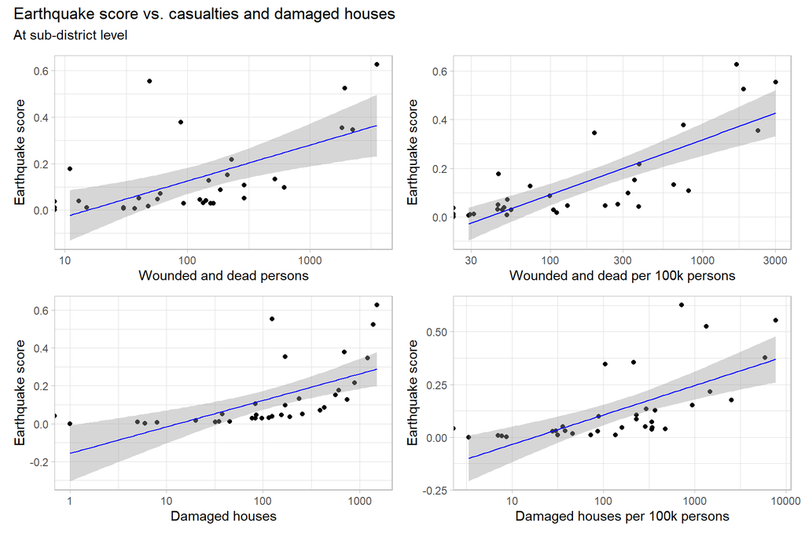